# Bev_Tucker_HW6

## Beverlyn Tucker

```
Professor: Dr. Ami Gates
IST-736 Text Mining WK6 Scikit Learn Review
Aug 11, 2020
```

## Introduction

This week is the review of Naive Bayes. Scikit Learn processing. Natural language processing (NLP) is an area of computer science and artificial intelligence concerned with the interactions between computers and human (natural) languages, particularly how to program computers to process and analyze large amounts of natural language data. It is the branch of machine learning, which is about analyzing any text and handling predictive analysis.

Sentiment analysis is the interpretation and classification of emotions (positive, negative, and neutral) within text data using text analysis techniques. Sentiment analysis tools allow businesses to identify customer sentiment toward products, brands, or services in online feedback. Scikit Learn is a free software machine learning library for Python programming language. Scikit-learn is written mainly in Python.

Let’s understand the various steps involved in text processing and the flow of NLP. This algorithm can be easily applied to any other kind of text like classify book into like Romance, Fiction, but for now, let’s use a restaurant review dataset to review negative or positive feedback.

## Data Analysis

The data from WK4 utilizing restaurant review. To the following model; Bernoulli distribution is the discrete probability distribution of a random variable which takes a binary, boolean output: 1 with probability p, and 0 with probability (1-p). The idea is that, whenever you are running an experiment which might lead either to success or to a failure, you can associate with your progress (labeled with 1) a probability p, while your in-success (labeled with 0) will have probability (1-p).

Binomial distribution describes the behavior of the outputs of n random experiments, each having a Bernoulli distribution with probability p.

Additionally, adding the random forest classifier. To compare which best model. It can be used both for classification and regression. It is also the most flexible and easy to use the algorithm.

## DATA PREPATION

```python
import os
import re
import numpy as np
import pandas as pd
import numpy as np
from nltk.stem.snowball import SnowballStemmer
from sklearn.metrics import confusion_matrix
from sklearn.model_selection import train_test_split
from sklearn.naive_bayes import BernoulliNB, MultinomialNB
from sklearn.feature_extraction.text import TfidfVectorizer, CountVectorizer
from sklearn.naive_bayes import BernoulliNB
from sklearn.metrics import accuracy_score
```

```python
df =pd.read_csv('C:/Users/bevst/Downloads/IST736/WK6/deception_data_converted_final_Adj.csv', engine='python')
```

```python
df.loc[:,['sentiment', 'review']]
```

|  | sentiment | review |
| --- | --- | --- |
| 0 | n | 'Mike\'s Pizza High Point NY Service was very ... |
| 1 | n | 'i really like this buffet restaurant in Marsh... |
| 2 | n | 'After I went shopping with some of my friend ... |
| 3 | n | 'Olive Oil Garden was very disappointing. I ex... |
| 4 | n | 'The Seven Heaven restaurant was never known f... |
| ... | ... | ... |
| 87 | p | 'Pastablities is a locally owned restaurant in... |
| 88 | p | 'I like the Pizza at Dominoes for their specia... |
| 89 | p | 'It was a really amazing Japanese restaurant. ... |
| 90 | p | 'How do I even pick a best experience at Joe\'... |
| 91 | p | 'My sister and I ate at this restaurant called... |

92 rows × 2 columns

```python
# Remove special characters and lower case words
for i in range(0, len(df)):
    df.iloc[i, 2] = re.sub('[\W\_]', ' ', df.iloc[i, 2]).lower()

print(df.head())
```

```
  lie sentiment                                             review
0   f         n   mike  s pizza high point ny service was very ...
1   f         n   i really like this buffet restaurant in marsh...
2   f         n   after i went shopping with some of my friend ...
3   f         n   olive oil garden was very disappointing  i ex...
4   f         n   the seven heaven restaurant was never known f...
```

```python
train=df
y=train['sentiment'].values
X=train['review'].values
```

```python
from sklearn.model_selection import train_test_split
X_train, X_test, y_train, y_test = train_test_split(X, y, test_size=0.4, random_state=0)
print(X_train.shape, y_train.shape, X_test.shape, y_test.shape)
print(X_train[0])
print(y_train[0])
print(X_test[0])
print(y_test[0])
```

```
(55,) (55,) (37,) (37,)
 my sister and i ate at this restaurant called matador  the overall look and ambiance of the restaurant was very appealing  we first ordered strawberry margaritas  which were really good then my sister ordered a spinach lasagna with alfredo sauce and i ordered pasta ravioli with marinara sauce  my s…
p
 after i went shopping with some of my friend we went to dodo restaurant for dinner  i found worm in one of the dishes    nan nan nan nan nan nan nan nan nan nan nan nan nan nan nan nan nan nan nan nan nan
n
```

```python
from sklearn.feature_extraction.text import CountVectorizer
from sklearn.feature_extraction.text import TfidfVectorizer

#  unigram term frequency vectorizer, set minimum document frequency to 5
unigram_count_vectorizer = CountVectorizer(encoding='latin-1', binary=True, min_df=5, stop_words='english')


#  unigram tfidf vectorizer, set minimum document frequency to 5
unigram_tfidf_vectorizer = TfidfVectorizer(encoding='latin-1', use_idf=True, min_df=5, stop_words='english')
```

```python
X_train_vec = unigram_count_vectorizer.fit_transform(X_train)


# check the content of a document vector
print(X_train_vec.shape)
print(X_train_vec[0].toarray())

# check the size of the constructed vocabulary
print(len(unigram_count_vectorizer.vocabulary_))

# print out the first 10 items in the vocabulary
print(list(unigram_count_vectorizer.vocabulary_.items())[:10])

# check word index in vocabulary
print(unigram_count_vectorizer.vocabulary_.get('imaginative'))
```

```
(55, 62)
[[1 0 0 1 0 0 0 0 0 0 0 0 0 0 1 0 0 0 0 0 0 1 0 0 0 0 0 0 0 0 0 1 0 0 0 0
  1 1 0 0 0 1 1 0 0 1 0 0 0 0 0 0 0 0 0 0 0 0 0 0 0 0]]
62
[('restaurant', 42), ('overall', 37), ('ordered', 36), ('really', 41), ('good', 21), ('sauce', 45), ('best', 3), ('amazing', 0), ('experience', 14), ('nan', 31)]
None
```

```python
##TF_IDF
X_train_tfidf = unigram_tfidf_vectorizer.fit_transform(X_train)

# check the content of a document vector
print(X_train_tfidf.shape)
print(X_train_tfidf[0].toarray())

# check the size of the constructed vocabulary
print(len(unigram_tfidf_vectorizer.vocabulary_))

# print out the first 10 items in the vocabulary
print(list(unigram_tfidf_vectorizer.vocabulary_.items())[:10])

# check word index in vocabulary
##print(unigram_tfidf_vectorizer.vocabulary_.get('adopt'))   ##('imaginative'))
```

```
(55, 62)
[[0.11021961 0.         0.         0.08109868 0.         0.
  0.         0.         0.         0.         0.         0.
  0.         0.         0.08320582 0.         0.         0.
  0.         0.         0.         0.08320582 0.         0.
  0.         0.         0.         0.         0.         0.
  0.         0.85739828 0.         0.         0.         0.
  0.29702362 0.24002799 0.         0.         0.         0.09031138
  0.12156472 0.         0.         0.25204331 0.         0.
  0.         0.         0.         0.         0.         0.
  0.         0.         0.         0.         0.         0.
  0.         0.        ]]
62
[('restaurant', 42), ('overall', 37), ('ordered', 36), ('really', 41), ('good', 21), ('sauce', 45), ('best', 3), ('amazing', 0), ('experience', 14), ('nan', 31)]
```

```python
X_test_vec = unigram_count_vectorizer.transform(X_test)

# print out #examples and #features in the test set
print(X_test_vec.shape)
```

```
(37, 62)
```

```python
##TFIDF

X_test_tfidf = unigram_tfidf_vectorizer.transform(X_test)

# print out #examples and #features in the test set
print(X_test_tfidf.shape)
```

```
(37, 62)
```

```python
# import the MNB module
from sklearn.naive_bayes import MultinomialNB

# initialize the MNB model
nb_clf= MultinomialNB()

# use the training data to train the MNB model
nb_clf.fit(X_train_vec,y_train)
```

```
MultinomialNB()
```

```python
# import the MNB module TFIDF
from sklearn.naive_bayes import MultinomialNB

# initialize the MNB model
nb_clf= MultinomialNB()

# use the training data to train the MNB model
nb_clf.fit(X_train_tfidf,y_train)

##nb_clf.fit(X_train_tfidf,y_train)
```

```
MultinomialNB()
```

```python
# use the training data to train the Bernoulli model TFIDF
from sklearn.naive_bayes import BernoulliNB

Bern_clf= BernoulliNB()
Bern_clf.fit(X_train_tfidf,y_train)

Bern_clf2= BernoulliNB()
Bern_clf2.fit(X_train_tfidf,y_train)
```

```
BernoulliNB()
```

```python
from sklearn.ensemble import RandomForestClassifier

model_RF = RandomForestClassifier(n_estimators = 501,
                            criterion = 'entropy')

model_RF.fit(X_train_tfidf,y_train)


model_RF2 = RandomForestClassifier(n_estimators = 501,
                            criterion = 'entropy')
model_RF2.fit(X_train_tfidf,y_train)
```

```
RandomForestClassifier(criterion='entropy', n_estimators=501)
```

```python
unigram_count_vectorizer.vocabulary_.get('worthless')
##for i in range(0,5):
 ## print(nb_clf.feature_log_prob_[i][unigram_count_vectorizer.vocabulary_.get('worthless')])
```

```python
##MNB Vectorizer

feature_ranks = sorted(zip(nb_clf.feature_log_prob_[0], unigram_count_vectorizer.get_feature_names()))
very_negative_features = feature_ranks[-5:]
print(very_negative_features)


## Bernoulli Vectorizer

feature_ranks = sorted(zip(Bern_clf.feature_log_prob_[0], unigram_count_vectorizer.get_feature_names()))
very_negative_features = feature_ranks[-5:]
print(very_negative_features)
```

```
[(-4.007359041403722, 'went'), (-3.8927183619579706, 'place'), (-3.7784550692048646, 'food'), (-3.7446838298323346, 'restaurant'), (-1.6732405209633203, 'nan')]
[(-1.0033021088637848, 'place'), (-0.6931471805599454, 'went'), (-0.5679840376059393, 'food'), (-0.4054651081081646, 'restaurant'), (-0.03390155167568132, 'nan')]
```

```python
##MNB TFIDF

feature_ranks = sorted(zip(nb_clf2.feature_log_prob_[0], unigram_count_vectorizer.get_feature_names()))
very_negative_features = feature_ranks[-5:]
print(very_negative_features)

## Bernoulli TFIDF

feature_ranks = sorted(zip(Bern_clf2.feature_log_prob_[0], unigram_count_vectorizer.get_feature_names()))
very_negative_features = feature_ranks[-5:]
print(very_negative_features)
```

```
[(-1.0033021088637848, 'place'), (-0.6931471805599454, 'went'), (-0.5679840376059393, 'food'), (-0.4054651081081646, 'restaurant'), (-0.03390155167568132, 'nan')]
[(-1.0033021088637848, 'place'), (-0.6931471805599454, 'went'), (-0.5679840376059393, 'food'), (-0.4054651081081646, 'restaurant'), (-0.03390155167568132, 'nan')]
```

```python
feature_ranks = sorted(zip(Bern_clf2.feature_log_prob_[0], unigram_count_vectorizer.get_feature_names()))
very_negative_features = feature_ranks[-5:]
print(very_negative_features)
```

```
[(-1.0033021088637848, 'place'), (-0.6931471805599454, 'went'), (-0.5679840376059393, 'food'), (-0.4054651081081646, 'restaurant'), (-0.03390155167568132, 'nan')]
```

```python
##MNB Vectorizer
nb_clf.score(X_test_vec,y_test)
```

```
0.8648648648648649
```

```python
##MNB TFIDF
nb_clf2.score(X_test_tfidf,y_test)
```

```
0.7837837837837838
```

```python
##Bernoulli Vectorizer
Bern_clf.score(X_test_vec,y_test)
```

```
0.7837837837837838
```

```python
##Bernoulli TFIDF
Bern_clf2.score(X_test_tfidf,y_test)
```

```
0.7837837837837838
```

```
Feature: 0, Score: 0.06483
Feature: 1, Score: 0.10434
Feature: 2, Score: 0.15828
Feature: 3, Score: 0.18964
Feature: 4, Score: 0.08964
Feature: 5, Score: 0.11167
Feature: 6, Score: 0.10460
Feature: 7, Score: 0.04952
Feature: 8, Score: 0.08657
Feature: 9, Score: 0.04090
```

[figure not shown]

```python
# random forest for feature importance on a classification problem
from sklearn.datasets import make_classification
from sklearn.ensemble import RandomForestClassifier
from matplotlib import pyplot
# define dataset
X, y = make_classification(n_samples=1000, n_features=10, n_informative=5, n_redundant=5, random_state=1)
# define the model
model = RandomForestClassifier()
model.fit(X, y)
# get importance
importance = model.feature_importances_
# summarize feature importance
for i,v in enumerate(importance):
	print('Feature: %0d, Score: %.5f' % (i,v))
# plot feature importance
pyplot.bar([x for x in range(len(importance))], importance)
pyplot.show()
```

## Naive Bayes MNB, Bernouli and Random Frorest Vectorizer

```python
# MNB vectorizer
y_pred = nb_clf.fit(X_train_vec, y_train).predict(X_test_vec)
cm=confusion_matrix(y_test, y_pred, labels=['n','p'])
print(cm)

##MNB vectorizer
from sklearn.metrics import precision_score
from sklearn.metrics import recall_score
print(precision_score(y_test, y_pred, average=None))
print(recall_score(y_test, y_pred, average=None))

from sklearn.metrics import classification_report
target_names = ['n','p']
print("Accuracy_of_Vec_MNB_Model = %2f%%" % (accuracy_score(y_test, y_pred)*100))
print(classification_report(y_test, y_pred, target_names=target_names))




##Bernoulli vectorizer
y_pred_Bern = Bern_clf2.fit(X_train_vec, y_train).predict(X_test_vec)
cm=confusion_matrix(y_test, y_pred_Bern, labels=['n','p'])
print(cm)

##Bernoulli Vectorization
from sklearn.metrics import precision_score
from sklearn.metrics import recall_score
print(precision_score(y_test, y_pred, average=None))
print(recall_score(y_test, y_pred_Bern, average=None))

from sklearn.metrics import classification_report
target_names = ['n','p']

print("Accuracy_of_Vec_Bernoulli_Model = %2f%%" % (accuracy_score(y_test, y_pred_Bern)*100))

print(classification_report(y_test, y_pred_Bern, target_names=target_names))



##Random Forest vectorizer
model_RF = nb_clf.fit(X_train_vec, y_train).predict(X_test_vec)
cm=confusion_matrix(y_test, model_RF, labels=['n','p'])
print(cm)

##Random Forest vectorizer
from sklearn.metrics import precision_score
from sklearn.metrics import recall_score
print(precision_score(y_test, model_RF, average=None))
print(recall_score(y_test, model_RF, average=None))

from sklearn.metrics import classification_report
target_names = ['n','p']
print("Accuracy_of_Vec_Random_Forest_Model = %2f%%" % (accuracy_score(y_test, model_RF)*100))
print(classification_report(y_test, model_RF, target_names=target_names))
```

```
[[15  3]
 [ 4 15]]
[0.78947368 0.83333333]
[0.83333333 0.78947368]
Accuracy_of_Vec_MNB_Model = 81.081081%
              precision    recall  f1-score   support

           n       0.79      0.83      0.81        18
           p       0.83      0.79      0.81        19

    accuracy                           0.81        37
   macro avg       0.81      0.81      0.81        37
weighted avg       0.81      0.81      0.81        37

[[12  6]
 [ 2 17]]
[0.78947368 0.83333333]
[0.66666667 0.89473684]
Accuracy_of_Vec_Bernoulli_Model = 78.378378%
              precision    recall  f1-score   support

           n       0.86      0.67      0.75        18
           p       0.74      0.89      0.81        19

    accuracy                           0.78        37
   macro avg       0.80      0.78      0.78        37
weighted avg       0.80      0.78      0.78        37

[[15  3]
 [ 4 15]]
[0.78947368 0.83333333]
[0.83333333 0.78947368]
Accuracy_of_Vec_Random_Forest_Model = 81.081081%
              precision    recall  f1-score   support

           n       0.79      0.83      0.81        18
           p       0.83      0.79      0.81        19

    accuracy                           0.81        37
   macro avg       0.81      0.81      0.81        37
weighted avg       0.81      0.81      0.81        37
```

## Naive Bayes MNB, Bernoulli and Random Frorest TFIDF

```python
##MNB dfidf
y_pred2 = nb_clf.fit(X_train_tfidf, y_train).predict(X_test_tfidf)
cm=confusion_matrix(y_test, y_pred2, labels=['n','p'])
print(cm)


##MNB TFIDF
from sklearn.metrics import precision_score
from sklearn.metrics import recall_score
print(precision_score(y_test, y_pred2, average=None))
print(recall_score(y_test, y_pred2, average=None))

from sklearn.metrics import classification_report
target_names = ['n','p']

print("Accuracy_of_TFIDF_MNB_Model = %2f%%" % (accuracy_score(y_test, y_pred2)*100))
print(classification_report(y_test, y_pred2, target_names=target_names))



##Bernoulli TFIDF
y_pred_Bern2 = Bern_clf2.fit(X_train_tfidf, y_train).predict(X_test_tfidf)
cm=confusion_matrix(y_test, y_pred_Bern2, labels=['n','p'])
print(cm)

##Bernoulli TFIDF
from sklearn.metrics import precision_score
from sklearn.metrics import recall_score
print(precision_score(y_test, y_pred_Bern2, average=None))
print(recall_score(y_test, y_pred_Bern2, average=None))

from sklearn.metrics import classification_report
target_names = ['n','p']
print("Accuracy_of_TFIDF_Bernoulli_Model = %2f%%" % (accuracy_score(y_test, y_pred_Bern2)*100))
print(classification_report(y_test, y_pred_Bern2, target_names=target_names))




##Random Forest TFIDF
y_pred_RF2 = Bern_clf2.fit(X_train_tfidf, y_train).predict(X_test_tfidf)
cm=confusion_matrix(y_test, y_pred_RF2, labels=['n','p'])
print(cm)

##Random Forest TFIDF
from sklearn.metrics import precision_score
from sklearn.metrics import recall_score
print(precision_score(y_test, y_pred_RF2, average=None))
print(recall_score(y_test, y_pred_RF2, average=None))

from sklearn.metrics import classification_report
target_names = ['n','p']
print("Accuracy_of_TFIDF_Randome_Forest_Model = %2f%%" % (accuracy_score(y_test, y_pred_RF2)*100))
print(classification_report(y_test, y_pred_RF2, target_names=target_names))
```

```
[[11  7]
 [ 0 19]]
[1.         0.73076923]
[0.61111111 1.        ]
Accuracy_of_TFIDF_MNB_Model = 81.081081%
              precision    recall  f1-score   support

           n       1.00      0.61      0.76        18
           p       0.73      1.00      0.84        19

    accuracy                           0.81        37
   macro avg       0.87      0.81      0.80        37
weighted avg       0.86      0.81      0.80        37

[[12  6]
 [ 2 17]]
[0.85714286 0.73913043]
[0.66666667 0.89473684]
Accuracy_of_TFIDF_Bernoulli_Model = 78.378378%
              precision    recall  f1-score   support

           n       0.86      0.67      0.75        18
           p       0.74      0.89      0.81        19

    accuracy                           0.78        37
   macro avg       0.80      0.78      0.78        37
weighted avg       0.80      0.78      0.78        37

[[12  6]
 [ 2 17]]
[0.85714286 0.73913043]
[0.66666667 0.89473684]
Accuracy_of_TFIDF_Randome_Forest_Model = 78.378378%
              precision    recall  f1-score   support

           n       0.86      0.67      0.75        18
           p       0.74      0.89      0.81        19

    accuracy                           0.78        37
   macro avg       0.80      0.78      0.78        37
weighted avg       0.80      0.78      0.78        37
```

## Naive Bayes Normalize MNB and Bernoulli Vectorizer

```python
from sklearn.naive_bayes import MultinomialNB
Norm_Vec = unigram_count_vectorizer.fit_transform(X_train)
bernoulliNB_clf = MultinomialNB(Norm_Vec, y_train)

from sklearn.pipeline import Pipeline
from sklearn.model_selection import cross_val_score

np.random.seed(222)
Bern_clf_pipe = Pipeline([('vect', CountVectorizer(encoding='latin-1', binary=True)),('Bern', MultinomialNB())])
scores = cross_val_score(Bern_clf_pipe, X, y, cv=3)
avg=sum(scores)/len(scores)
print(avg)


## Bernoulli Normalize Vectorizer

from sklearn.naive_bayes import BernoulliNB
Norm_Vec = unigram_count_vectorizer.fit_transform(X_train)
bernoulliNB_clf = BernoulliNB(Norm_Vec, y_train)

from sklearn.pipeline import Pipeline
from sklearn.model_selection import cross_val_score


Bern_clf_pipe = Pipeline([('vect', CountVectorizer(encoding='latin-1', binary=True)),('Bern', BernoulliNB())])
scores = cross_val_score(Bern_clf_pipe, X, y, cv=3)
avg=sum(scores)/len(scores)
print(avg)



##Random Forest Normalize TFIDF

from sklearn.ensemble import RandomForestClassifier
Norm_Vec = unigram_count_vectorizer.fit_transform(X_train)
bernoulliNB_clf = RandomForestClassifier(Norm_Vec, y_train)

from sklearn.pipeline import Pipeline
from sklearn.model_selection import cross_val_score


RF_clf_pipe = Pipeline([('vect', CountVectorizer(encoding='latin-1', binary=True)),('RF', RandomForestClassifier())])
scores = cross_val_score(RF_clf_pipe, X, y, cv=3)
avg=sum(scores)/len(scores)
print(avg)
```

[output not shown]

[output cut: 60 more lines]

[output not shown]

```
0.8587813620071684
0.7612903225806452
0.8157706093189964
```

## Normalized Vectorizer

MNB > 0.8587813620071684 Bernoulli > 0.7612903225806452 RandomForest > 0.8157706093189964

MNB has a better result on Normalized vectorizer

## Naive Bayes Normalize MNB and Bernoulli TFIDF

```python
from sklearn.naive_bayes import MultinomialNB
Norm_TFIDF_MNB = unigram_tfidf_vectorizer.fit_transform(X_train)
MNB_TFIDF = MultinomialNB(Norm_TFIDF_MNB, y_train)

from sklearn.pipeline import Pipeline
from sklearn.model_selection import cross_val_score

np.random.seed(222)
bernoulliNB_clf = Pipeline([('TFIDF', TfidfVectorizer(encoding='latin-1', norm='l2', binary=True)),('MNB', MultinomialNB())])
scores = cross_val_score(bernoulliNB_clf, X, y, cv=3)
avg=sum(scores)/len(scores)
print(avg)


###Bernoulli Normalize TFIDF
from sklearn.naive_bayes import BernoulliNB
Norm_TFIDF_Bern = unigram_tfidf_vectorizer.fit_transform(X_train)
bernoulliNB_clf = BernoulliNB(Norm_TFIDF, y_train)

from sklearn.pipeline import Pipeline
from sklearn.model_selection import cross_val_score


bernoulliNB_clf = Pipeline([('TFIDF', TfidfVectorizer(encoding='latin-1', norm='l2', binary=True)),('Bern', BernoulliNB())])
scores = cross_val_score(Bern_clf_pipe, X, y, cv=3)
avg=sum(scores)/len(scores)
print(avg)



##Random Forest Normalize TFIDF
from sklearn.ensemble import RandomForestClassifier
Norm_TFIDF_RF = unigram_tfidf_vectorizer.fit_transform(X_train)
Random_Forest_clf = RandomForestClassifier(Norm_TFIDF_RF, y_train)

from sklearn.pipeline import Pipeline
from sklearn.model_selection import cross_val_score


Norm_RandomForest_clf = Pipeline([('TFIDF', TfidfVectorizer(encoding='latin-1', norm='l2', binary=True)),('RF', RandomForestClassifier())])
scores = cross_val_score(RandomForest_clf, X, y, cv=3)
avg=sum(scores)/len(scores)
print(avg)
```

[output not shown]

[output cut: 60 more lines]

[output not shown]

[output not shown]

## Normalize Results

MNB still taking the lead on Normalization

```python
import numpy as np
words, values = pd.DataFrame(np.array(unigram_tfidf_vectorizer.get_feature_names())), pd.DataFrame(np.array(Norm_TFIDF_MNB.mean(axis=0))).transpose()

# Build a dataframe with the words and tf-idf results to view words with both the highest and lowest scores.
review_tfidf_Norm = pd.concat([words, values], axis=1)
review_tfidf_Norm.columns = ['Words', 'tf-idf']
review_tfidf_Norm = review_tfidf_Norm.sort_values(by=['tf-idf'], ascending=False)

print('MNB_Norm Top 10 highest frequency: ')
print(review_tfidf_Norm.iloc[:10, :], '\n')
```

```
MNB_Norm Top 10 highest frequency:
         Words    tf-idf
31         nan  0.856675
16        food  0.066023
42  restaurant  0.061876
38       place  0.041440
3         best  0.039737
47     service  0.035239
14  experience  0.035160
21        good  0.034897
36     ordered  0.031875
60        went  0.031525
```

```python
import numpy as np
words, values = pd.DataFrame(np.array(unigram_tfidf_vectorizer.get_feature_names())), pd.DataFrame(np.array(Norm_TFIDF_Bern.mean(axis=0))).transpose()

# Build a dataframe with the words and tf-idf results to view words with both the highest and lowest scores.
review_tfidf_Norm = pd.concat([words, values], axis=1)
review_tfidf_Norm.columns = ['Words', 'tf-idf']
review_tfidf_Norm = review_tfidf_Norm.sort_values(by=['tf-idf'], ascending=False)

print('Bern_Norm Top 10 highest frequency: ')
print(review_tfidf_Norm.iloc[:10, :], '\n')
```

```
Bern_Norm Top 10 highest frequency:
         Words    tf-idf
31         nan  0.856675
16        food  0.066023
42  restaurant  0.061876
38       place  0.041440
3         best  0.039737
47     service  0.035239
14  experience  0.035160
21        good  0.034897
36     ordered  0.031875
60        went  0.031525
```

### Top 10 Word frequency that is normalized

The top 10 word and frequency are the both same MNB and Bernoulli

## leman & stemmer

```python
X_train
```

[output not shown]

[output cut: 40 more lines]

```python
# Lemmatization of the corpora to group words.
from nltk.stem import WordNetLemmatizer
lemmatizer = WordNetLemmatizer()

# Define the lemmatizer then inserted into the TF-IDF tokenizer
def lemm_words(doc):
    return (lemmatizer.lemmatize(w) for w in vectorizer(doc))

#Initialize vectorizer and then corpora is parsed through the lemmaitized tokenize
vectorizer = TfidfVectorizer(token_pattern='[^\W\_\0-9]+', stop_words='english').build_tokenizer()
tf_lemm = TfidfVectorizer(tokenizer=lemm_words, token_pattern='[^\W\_\0-9]+', stop_words='english', min_df=1, max_df=1,
                          analyzer='word', max_features=500)
results = tf_lemm.fit_transform(X_train)

print(results.shape)
```

```
(55, 500)
```

```python
# Build data frames to store words and TF-IDF results
words, values = pd.DataFrame(np.array(tf_lemm.get_feature_names())), pd.DataFrame(np.array(results.mean(axis=0))).transpose()

# Build a dataframe with the words and tf-idf results to view words with both the highest and lowest scores.
final_results = pd.concat([words, values], axis=1)
final_results.columns = ['Words', 'tf-idf']
final_results = final_results.sort_values(by=['tf-idf'], ascending=False)

print('Top 5 highest frequency: ')
print(final_results.iloc[:5, :], '\n')

print('Bottom 5 lowest frequency: ')
print(final_results.iloc[495:, :])
```

```
Top 5 highest frequency:
       Words    tf-idf
197     gone  0.018182
29   awesome  0.018182
483  weekend  0.018182
412     soon  0.018182
249   jersey  0.018182

Bottom 5 lowest frequency:
             Words    tf-idf
324     personally  0.001363
322      perceived  0.001363
319          peeve  0.001363
112  conspicuously  0.001363
54          bottle  0.001363
```

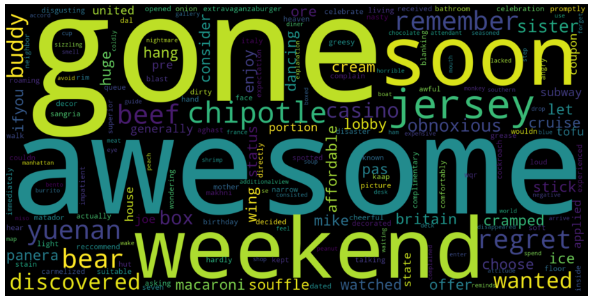

```python
# Create a dictionary with the words and TF-IDF values that will be passed into WordCloud()
from wordcloud import WordCloud, ImageColorGenerator
d = {}
for a, x in final_results.values:
    d[a] = x

# Adjust image parameters to increase height and width of figure, create word cloud, and show image
plt.rcParams['figure.figsize'] = [15, 10]
wordcloud = WordCloud(scale=5)
wordcloud.generate_from_frequencies(frequencies=d)
plt.figure()
plt.imshow(wordcloud, interpolation="bilinear")
plt.axis("off")
plt.show()
```

## Result Summary

Base on the overall results MNB_Model has a better result for both countvectorizer and TFIDF. And on normalized results, MNB consistently took the lead. If I had time, it would be interesting to take out the three-letter words. This might change the result significantly. Knowingly after showing the TFIDF final results in the word cloud, there were multiple three-letter words.

## Conclusion

The review is fundamental to the wide study in today’s generation. Most customer is searching for a reference point, before heading to establishments, and where to buy and where to eat. According to planet marketing, 88% of respondents trust online reviews. So, predicting future events are crucial.

Machine learning is important and required multiple iterations and multiple reviews to avoid unfavorable scrutiny.

The Multinomial Naive Bayes model has been leading across the study. For this dataset, it proved superior to the three models that has created.  
However, this model is not perfect, either. It is imperative before drawing any conclusions as to which of the two models is the better one on Naive Bayes, should test the model with bigger data sets with multiple parameters. This would provide a better understanding of which of the Naive Bayes Bernoulli vs. Multinomial.